Victor Omondi | Blog

# Hyperparameter Tuning with Python

perform hyperparameter tuning techniques to your most accurate model in an effort to achieve optimal predictions.

Sep 21, 2021 • Victor Omondi • 13 min read

machine-learning hyperparameter-tuning

- Libraries
  - Libraries setup
- 1. Research Question Definition
  - 1.1 Data Analysis Question
  - 1.2 Metric For Success
  - 1.3 The Context
  - 1.4 Experimental Design
  - 1.5 Data Relevance
  - 2. Data Cleaning & Data Preparation
  - 2.1 Loading and Preview Datasets
    - Dataset Glossary
  - Data Exploration
  - Handling Duplicates and Missing Values
  - Checking for anomalies
  - Outliers visualization
  - Records with outliers
- 3. Data Analysis
  - 3.1 Univariate Data Analysis
    - Top 10 Most common hosts
    - the top 10 most common neighbourhoods
    - the most common room types
    - distribution of price
    - the top 10 most common minimum number of nights to spend
  - 3.2 Bivariate Analysis
    - price by room type
    - average price by neighbourhood
    - average price by minimum_nights
  - 3.3 Feature Engineering
- 4. Data Modeling
  - 4.1 Normal Modeling
  - 4.2 Modeling with Grid Search
  - 4.3 Modeling with Random Search
  - 4.4 Modeling with Bayesian Optimization
- 5. Summary of Findings
- 6. Recommendations
- 7. Challenging the Solution

# Libraries

```python
import warnings

import pandas as pd
import numpy as np

import matplotlib.pyplot as plt
import seaborn as sns

from sklearn.preprocessing import (LabelEncoder,
                                   StandardScaler)
from sklearn.model_selection import (train_test_split,
                                     cross_val_score,
                                     GridSearchCV,
                                     RandomizedSearchCV, BaseCrossValidator)
from sklearn.tree import DecisionTreeRegressor
from sklearn.ensemble import RandomForestRegressor
from sklearn.metrics import (mean_squared_error,
                             r2_score)

from hyperopt import hp, fmin, tpe, rand, STATUS_OK, Trials
```

## Libraries setup

```python
%matplotlib inline
plt.style.use("ggplot")
pd.set_option("display.max_columns", None)
pd.set_option("display.max_colwidth", None)
```

# 1. Research Question Definition

## 1.1 Data Analysis Question

We will be performing hyperparameter tuning techniques to the most accurate model in an effort to achieve optimal predictions.

## 1.2 Metric For Success

This will be a regression task, We will use the regression metrics to determine how the model works:

## 1.3 The Context

Build a solution the would make optimal predictions of rental prices for the city of Amsterdam.

## 1.4 Experimental Design

- Loading the dataset
- Exploring the dataset
- Data manipulation, data cleaning and visualization
- Data modeling
- Hyperparameter tuning
- Conclusion and recommendation

## 1.5 Data Relevance

The Data Provided in relevant to the research question

## 2. Data Cleaning & Data Preparation

## 2.1 Loading and Preview Datasets

```python
rentals = pd.read_csv("datasets/raw/listing_summary.csv")
rentals.head()
```

|  | id | name | host_id | host_name | neighbourhood_group | neighbourhood | latitude | longitude | room_type | price | minimum_nights | number_of_reviews | last_review | reviews_per_month | calculated_host_listings_count | availability_365 |
| --- | --- | --- | --- | --- | --- | --- | --- | --- | --- | --- | --- | --- | --- | --- | --- | --- |
| 0 | 2818 | Quiet Garden View Room & Super Fast WiFi | 3159 | Daniel | NaN | Oostelijk Havengebied - Indische Buurt | 52.36575 | 4.94142 | Private room | 59 | 3 | 278 | 2020-02-14 | 2.06 | 1 | 169 |
| 1 | 20168 | Studio with private bathroom in the centre 1 | 59484 | Alexander | NaN | Centrum-Oost | 52.36509 | 4.89354 | Private room | 100 | 1 | 340 | 2020-04-09 | 2.76 | 2 | 106 |
| 2 | 25428 | Lovely apt in City Centre (w.lift) near Jordaan | 56142 | Joan | NaN | Centrum-West | 52.37297 | 4.88339 | Entire home/apt | 125 | 14 | 5 | 2020-02-09 | 0.18 | 1 | 132 |
| 3 | 27886 | Romantic, stylish B&B houseboat in canal district | 97647 | Flip | NaN | Centrum-West | 52.38761 | 4.89188 | Private room | 155 | 2 | 217 | 2020-03-02 | 2.15 | 1 | 172 |
| 4 | 28871 | Comfortable double room | 124245 | Edwin | NaN | Centrum-West | 52.36719 | 4.89092 | Private room | 75 | 2 | 332 | 2020-03-16 | 2.82 | 3 | 210 |

### Dataset Glossary

Before starting the analysis, let's load the glossary to understand the column descriptions

```python
with open("datasets/raw/Glossary - Sheet1 (1).csv", encoding='utf8') as file:
    print(file.read())
```

[output not shown]

## Data Exploration

The `name` column contains the basic information about the Airbnb room, since this column won't be of any help in our analysis or modeling, we will drop the column

```python
rentals.drop(columns=['name'], inplace=True)
rentals.shape
```

```
(19362, 15)
```

The dataset has over 19362 rentals with 15 rentals information. Each row represents an Airbnb listing

```python
rentals.info()
```

```
<class 'pandas.core.frame.DataFrame'>
RangeIndex: 19362 entries, 0 to 19361
Data columns (total 15 columns):
 #   Column                          Non-Null Count  Dtype
---  ------                          --------------  -----
 0   id                              19362 non-null  int64
 1   host_id                         19362 non-null  int64
 2   host_name                       19358 non-null  object
 3   neighbourhood_group             0 non-null      float64
 4   neighbourhood                   19362 non-null  object
 5   latitude                        19362 non-null  float64
 6   longitude                       19362 non-null  float64
 7   room_type                       19362 non-null  object
 8   price                           19362 non-null  int64
 9   minimum_nights                  19362 non-null  int64
 10  number_of_reviews               19362 non-null  int64
 11  last_review                     17078 non-null  object
 12  reviews_per_month               17078 non-null  float64
 13  calculated_host_listings_count  19362 non-null  int64
 14  availability_365                19362 non-null  int64
dtypes: float64(4), int64(7), object(4)
memory usage: 2.2+ MB
```

`neighbourhood_group` 19362 missing values, that means every row in this column is a missing value. `last_review` and `reviews_per_month` have the same number of missing values.

## Handling Duplicates and Missing Values

We will start by

- droping any duplicates if any,
- remove the `neighbourhood_group`
- drop records with missing values for `last_review` and `reviews_per_month`

```python
rentals.drop_duplicates(inplace=True)
rentals.shape
```

```
(19362, 15)
```

There were no duplicates in the dataset. Let's continue by checking missing values and dropping them

```python
rentals.isnull().sum()
```

```
id                                    0
host_id                               0
host_name                             4
neighbourhood_group               19362
neighbourhood                         0
latitude                              0
longitude                             0
room_type                             0
price                                 0
minimum_nights                        0
number_of_reviews                     0
last_review                        2284
reviews_per_month                  2284
calculated_host_listings_count        0
availability_365                      0
dtype: int64
```

```python
rentals.drop(columns=['neighbourhood_group'], inplace=True)
rentals.dropna(inplace=True)
rentals.isnull().sum()
```

```
id                                0
host_id                           0
host_name                         0
neighbourhood                     0
latitude                          0
longitude                         0
room_type                         0
price                             0
minimum_nights                    0
number_of_reviews                 0
last_review                       0
reviews_per_month                 0
calculated_host_listings_count    0
availability_365                  0
dtype: int64
```

```python
rentals.shape
```

```
(17075, 14)
```

After removing the missing values, the dataset now has 17075 Airbnb listings

## Checking for anomalies

To ensure there are no anomalies in the dataset, we will check the number of unique items in every column

```python
cols = rentals.columns.to_list()

for col in cols:
    print(f"{col:>34} No. of Unique Items:{rentals[col].nunique():>8}")
```

```
                                id No. of Unique Items:   17075
                           host_id No. of Unique Items:   15182
                         host_name No. of Unique Items:    5382
                     neighbourhood No. of Unique Items:      22
                          latitude No. of Unique Items:    5720
                         longitude No. of Unique Items:    9193
                         room_type No. of Unique Items:       4
                             price No. of Unique Items:     422
                    minimum_nights No. of Unique Items:      60
                 number_of_reviews No. of Unique Items:     422
                       last_review No. of Unique Items:    1590
                 reviews_per_month No. of Unique Items:     703
    calculated_host_listings_count No. of Unique Items:      23
                  availability_365 No. of Unique Items:     366
```

## Outliers visualization

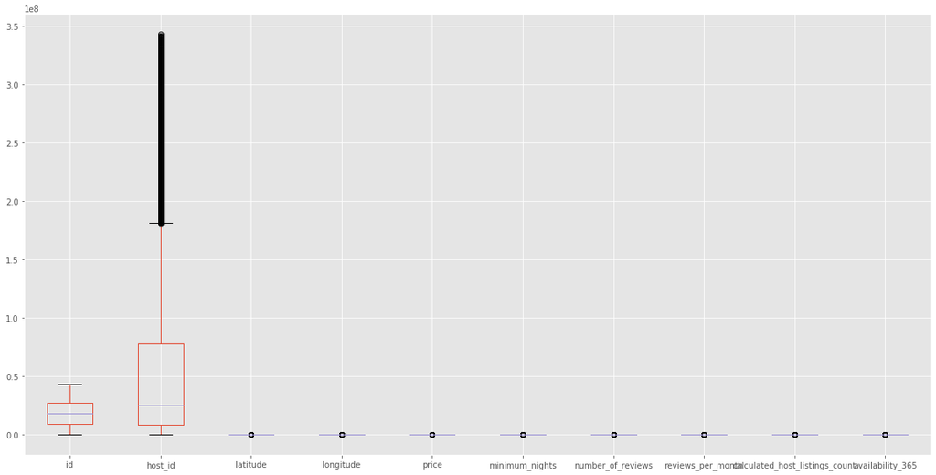

```python
plt.figure(figsize=(20,10))
rentals.boxplot()
plt.show()
```

## Records with outliers

```python
q1 = rentals.quantile(.25)
q3 = rentals.quantile(.75)
iqr = q3 - q1
outliers_df = rentals[
    ((rentals < (q1 - 1.5*iqr)) | (rentals > (q3 + 1.5*iqr))).any(axis=1)
]
outliers_df.shape
```

```
(8544, 14)
```

There are Over 8500 outliers in the dataset

```python
outliers_df.sample(5)
```

|  | id | host_id | host_name | neighbourhood | latitude | longitude | room_type | price | minimum_nights | number_of_reviews | last_review | reviews_per_month | calculated_host_listings_count | availability_365 |
| --- | --- | --- | --- | --- | --- | --- | --- | --- | --- | --- | --- | --- | --- | --- |
| 12117 | 22620913 | 2888051 | Lokke | Noord-West | 52.41524 | 4.89218 | Entire home/apt | 80 | 4 | 2 | 2018-05-06 | 0.08 | 1 | 0 |
| 3511 | 7166128 | 16634603 | Hermen | Centrum-Oost | 52.36991 | 4.92621 | Entire home/apt | 110 | 5 | 7 | 2018-08-19 | 0.12 | 1 | 0 |
| 15707 | 32722735 | 246045083 | Babette | De Baarsjes - Oud-West | 52.36514 | 4.86184 | Entire home/apt | 120 | 2 | 8 | 2019-06-29 | 0.64 | 1 | 0 |
| 13425 | 26037649 | 193680275 | Merle | Westerpark | 52.38374 | 4.87314 | Entire home/apt | 125 | 5 | 5 | 2018-11-18 | 0.24 | 1 | 0 |
| 730 | 1277443 | 6952882 | Jason & Lotte | Bos en Lommer | 52.38129 | 4.85746 | Entire home/apt | 98 | 5 | 4 | 2014-07-07 | 0.06 | 1 | 0 |

Let's check the percentage of outliers to the original dataset

```python
print(f"Percentage of outliers: {outliers_df.shape[0]/rentals.shape[0]*100:.2f}")
```

```
Percentage of outliers: 50.04
```

It would be tricky to drop the records with outliers since that will reduce our dataset by half so we will leave them there. However, we will drop the host_id variable later on, right before modeling.

# 3. Data Analysis

## 3.1 Univariate Data Analysis

### Top 10 Most common hosts

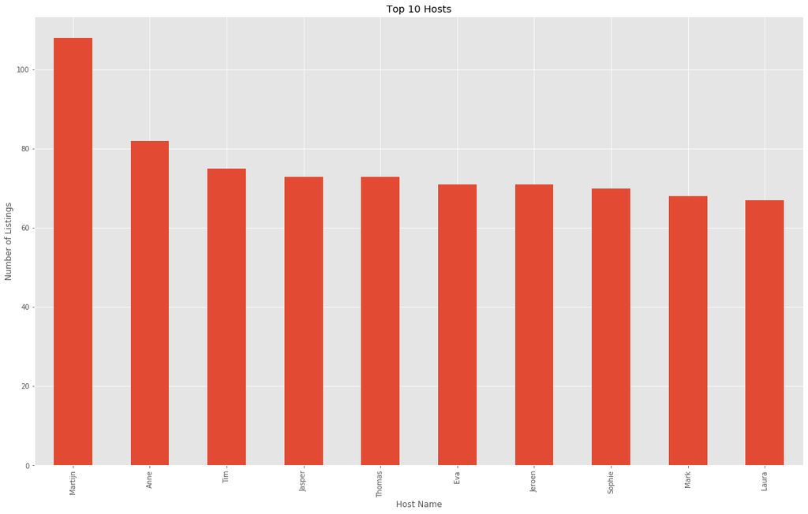

```python
plt.figure(figsize=(20,12))
rentals.host_name.value_counts()[:10].plot(kind='bar')
plt.title("Top 10 Hosts")
plt.xlabel("Host Name")
plt.ylabel("Number of Listings")
plt.show()
```

Martijn is the host name with most listings in the Airbnb rentals listing.

### the top 10 most common neighbourhoods

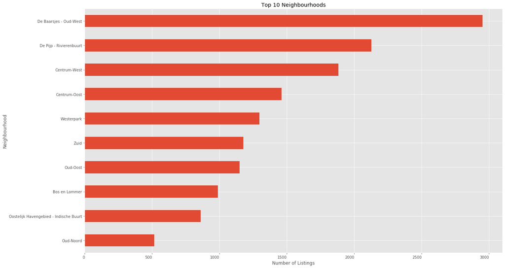

```python
plt.figure(figsize = (20, 12))
rentals.neighbourhood.value_counts()[:10].sort_values().plot(kind = 'barh')
plt.xticks(ha = "right")
plt.title("Top 10 Neighbourhoods")
plt.xlabel("Number of Listings")
plt.ylabel("Neighbourhood")
plt.show()
```

De Baarsjes - Oud-West Had the most number of rental listings

### the most common room types

```python
rentals.room_type.value_counts()
```

```
Entire home/apt    13308
Private room        3497
Hotel room           232
Shared room           38
Name: room_type, dtype: int64
```

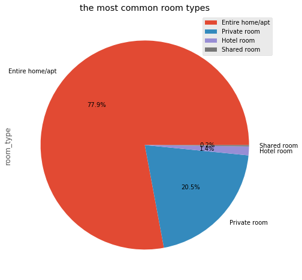

```python
plt.figure(figsize=(8,8))
rentals.room_type.value_counts().plot(kind='pie', autopct="%0.1f%%", labels=rentals.room_type.value_counts().index)
plt.legend()
plt.title("the most common room types")
plt.show()
```

### distribution of price

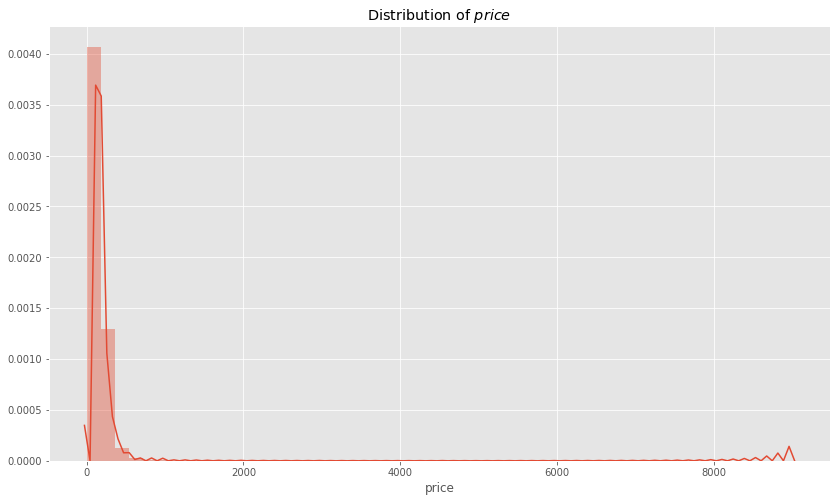

```python
plt.figure(figsize = (14,8))
sns.distplot(rentals.price)
plt.title("Distribution of $price$")
plt.show()
```

The distribution of price is skewed to the right and is not continous.

### the top 10 most common minimum number of nights to spend

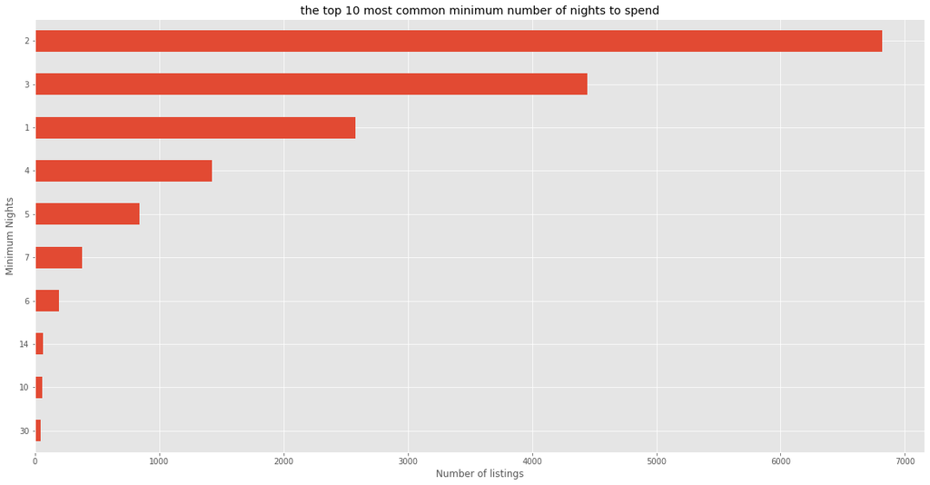

```python
plt.figure(figsize=(20,10))
rentals.minimum_nights.value_counts()[:10].sort_values().plot(kind='barh')
plt.title("the top 10 most common minimum number of nights to spend")
plt.xlabel("Number of listings")
plt.ylabel("Minimum Nights")
plt.show()
```

The most common minimum number of nights to spend is 2.

## 3.2 Bivariate Analysis

### price by room type

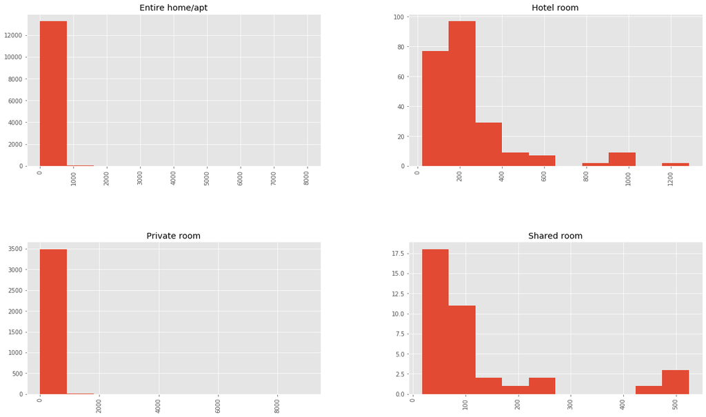

```python
rentals.hist('price', by='room_type', figsize=(20,12))
plt.show()
```

### average price by neighbourhood

```python
rentals.groupby('neighbourhood')['price'].mean().sort_values(ascending=False)
```

```
neighbourhood
Centrum-West                              203.653397
Centrum-Oost                              190.534247
Zuid                                      178.813243
Oud-Noord                                 168.763566
De Pijp - Rivierenbuurt                   166.601787
IJburg - Zeeburgereiland                  157.723077
Westerpark                                151.241140
De Baarsjes - Oud-West                    149.376228
Oud-Oost                                  144.606957
Watergraafsmeer                           141.199125
Buitenveldert - Zuidas                    137.690355
Oostelijk Havengebied - Indische Buurt    135.101163
Noord-Oost                                130.495833
Noord-West                                126.318885
Bos en Lommer                             122.525304
De Aker - Nieuw Sloten                    121.268908
Slotervaart                               119.791549
Geuzenveld - Slotermeer                   113.937143
Osdorp                                    103.418182
Gaasperdam - Driemond                      96.317757
Bijlmer-Centrum                            91.434343
Bijlmer-Oost                               89.696629
Name: price, dtype: float64
```

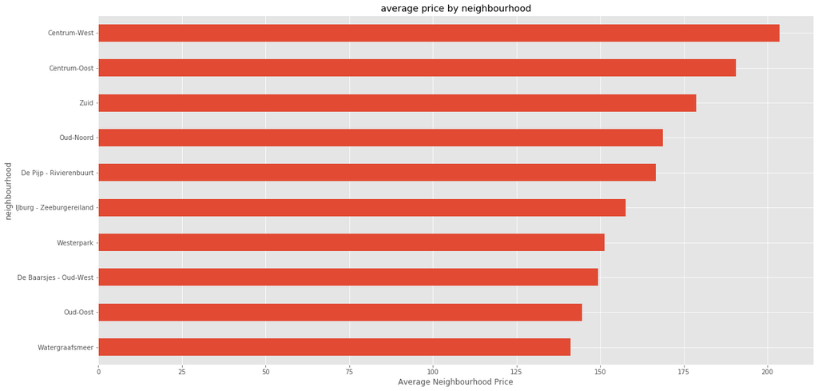

```python
plt.figure(figsize=(20, 10))
rentals.groupby('neighbourhood')['price'].mean().sort_values(ascending=False)[:10].sort_values().plot(kind='barh')
plt.xlabel("Average Neighbourhood Price")
plt.title("average price by neighbourhood")
plt.show()
```

Based on neighbour hood, Centrum West Has the highest average weight of listings.

### average price by minimum_nights

```python
rentals.groupby('minimum_nights')['price'].mean().sort_values(ascending=False)[:15]
```

```
minimum_nights
365     3000.000000
200      999.000000
99       999.000000
52       429.000000
30       331.551020
222      300.000000
27       275.000000
48       250.000000
31       243.750000
150      203.000000
21       201.761905
15       197.888889
1000     185.000000
240      180.000000
28       175.900000
Name: price, dtype: float64
```

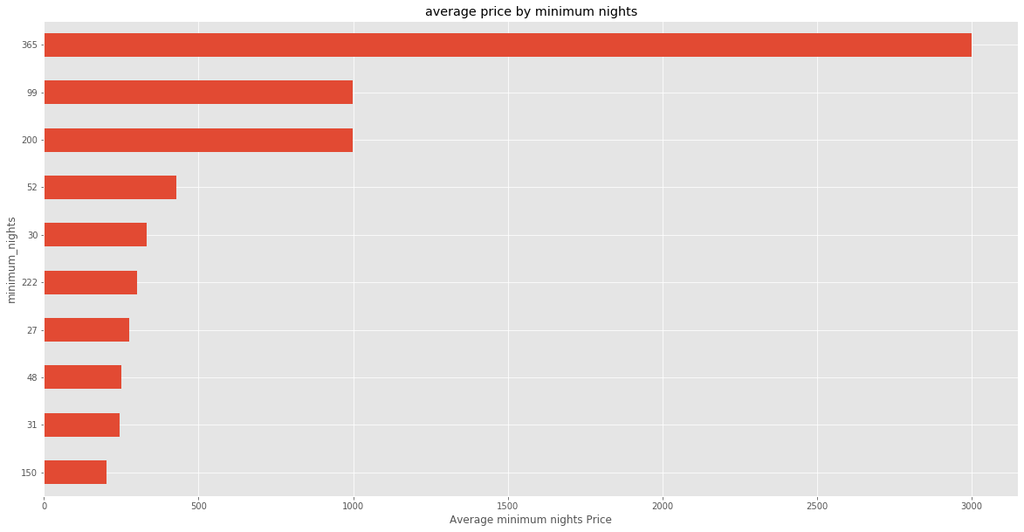

```python
plt.figure(figsize=(20, 10))
rentals.groupby('minimum_nights')['price'].mean().sort_values(ascending=False)[:10].sort_values().plot(kind='barh')
plt.xlabel("Average minimum nights Price")
plt.title("average price by minimum nights")
plt.show()
```

By average, those who spend 365 nights spend most price

## 3.3 Feature Engineering

```python
rentals.head()
```

|  | id | host_id | host_name | neighbourhood | latitude | longitude | room_type | price | minimum_nights | number_of_reviews | last_review | reviews_per_month | calculated_host_listings_count | availability_365 |
| --- | --- | --- | --- | --- | --- | --- | --- | --- | --- | --- | --- | --- | --- | --- |
| 0 | 2818 | 3159 | Daniel | Oostelijk Havengebied - Indische Buurt | 52.36575 | 4.94142 | Private room | 59 | 3 | 278 | 2020-02-14 | 2.06 | 1 | 169 |
| 1 | 20168 | 59484 | Alexander | Centrum-Oost | 52.36509 | 4.89354 | Private room | 100 | 1 | 340 | 2020-04-09 | 2.76 | 2 | 106 |
| 2 | 25428 | 56142 | Joan | Centrum-West | 52.37297 | 4.88339 | Entire home/apt | 125 | 14 | 5 | 2020-02-09 | 0.18 | 1 | 132 |
| 3 | 27886 | 97647 | Flip | Centrum-West | 52.38761 | 4.89188 | Private room | 155 | 2 | 217 | 2020-03-02 | 2.15 | 1 | 172 |
| 4 | 28871 | 124245 | Edwin | Centrum-West | 52.36719 | 4.89092 | Private room | 75 | 2 | 332 | 2020-03-16 | 2.82 | 3 | 210 |

```python
rentals['room_type_encoded'] = LabelEncoder().fit_transform(rentals.room_type)
rentals.head()
```

|  | id | host_id | host_name | neighbourhood | latitude | longitude | room_type | price | minimum_nights | number_of_reviews | last_review | reviews_per_month | calculated_host_listings_count | availability_365 | room_type_encoded |
| --- | --- | --- | --- | --- | --- | --- | --- | --- | --- | --- | --- | --- | --- | --- | --- |
| 0 | 2818 | 3159 | Daniel | Oostelijk Havengebied - Indische Buurt | 52.36575 | 4.94142 | Private room | 59 | 3 | 278 | 2020-02-14 | 2.06 | 1 | 169 | 2 |
| 1 | 20168 | 59484 | Alexander | Centrum-Oost | 52.36509 | 4.89354 | Private room | 100 | 1 | 340 | 2020-04-09 | 2.76 | 2 | 106 | 2 |
| 2 | 25428 | 56142 | Joan | Centrum-West | 52.37297 | 4.88339 | Entire home/apt | 125 | 14 | 5 | 2020-02-09 | 0.18 | 1 | 132 | 0 |
| 3 | 27886 | 97647 | Flip | Centrum-West | 52.38761 | 4.89188 | Private room | 155 | 2 | 217 | 2020-03-02 | 2.15 | 1 | 172 | 2 |
| 4 | 28871 | 124245 | Edwin | Centrum-West | 52.36719 | 4.89092 | Private room | 75 | 2 | 332 | 2020-03-16 | 2.82 | 3 | 210 | 2 |

```python
rentals.neighbourhood.nunique()
```

```
22
```

```python
rentals_2 = rentals.drop(columns=['id', 'host_id', 'host_name', 'neighbourhood', 'last_review', 'room_type'])
rentals_2.head()
```

|  | latitude | longitude | price | minimum_nights | number_of_reviews | reviews_per_month | calculated_host_listings_count | availability_365 | room_type_encoded |
| --- | --- | --- | --- | --- | --- | --- | --- | --- | --- |
| 0 | 52.36575 | 4.94142 | 59 | 3 | 278 | 2.06 | 1 | 169 | 2 |
| 1 | 52.36509 | 4.89354 | 100 | 1 | 340 | 2.76 | 2 | 106 | 2 |
| 2 | 52.37297 | 4.88339 | 125 | 14 | 5 | 0.18 | 1 | 132 | 0 |
| 3 | 52.38761 | 4.89188 | 155 | 2 | 217 | 2.15 | 1 | 172 | 2 |
| 4 | 52.36719 | 4.89092 | 75 | 2 | 332 | 2.82 | 3 | 210 | 2 |